# Hierarchical Model

Tati Micheletti

26/04/2020

## Hierarchical scale model

### Model 1:

Model 1 is composed of one equation, where the coefficients for disturbance come from the same hyperprior.

```r
        #MODEL 1: 1 equation + ZI
    iSMCode <- nimbleCode({

      ######## PRIORS ########
      #Zero inflation - habitat suitability
      phi ~ dunif(0, 1) # proportion of suitable sites (we need to keep phi between 0 and 1)

      # Coefficient for disturbance
      mu.beta ~ dunif(-40, 40)
      tau.beta ~ T(dgamma(1, 1), 0.01, 100)
      sd.beta <- 1/pow(tau.beta, 2) # cluster heterogeneity in lambda
      for (b in 1:Nbeta) {
        beta[b] ~ dnorm(mu.beta, tau.beta) # Hyperparameter for beta coefficients # No idea what to put here!
      }

      # Random effect
      tau.clusters ~ T(dgamma(1, 1), 0.01, 100)
      sd.cluster <- 1/pow(tau.clusters, 2) # year heterogeneity in lambda
      tau.year ~ T(dgamma(1, 1), 0.01, 100)
      sd.year <- 1/pow(tau.year, 2) # cluster heterogeneity in lambda
      for (j in 1:NClusters) {
        clusterRanEff[j] ~ dnorm(0, tau.clusters) # Note plural on tau.clusters, different than tau.clusters
        # random cluster effects in log(density)
      }
      for (y in 1:NYears) {
        YearRanEff[y] ~ dnorm(0, tau.year)
        # random year effects in log(density)
      }

      ##### END OF PRIORS ####

      for (i in 1:nvisits){ # each sample point / each row of the data table
        omega[i] ~ dbern(phi) # Habitat suitability --> zero inflation (if phi = 0, unsuitable)
        # Local scale
        yearInd <- YearIndex[i]
        clusterInd <- ClusterIndex[i]
        counts[i]  ~ dpois(mu.poisson[i])
        mu.poisson[i] <- omega[i] * lambda[i]
        lambda[i] <- exp(loglambda[i])
        loglambda[i] <- logDensity[i] + beta[1] * State_P_500[i] + beta[2] * State_P_100[i] + offset[i] +
          clusterRanEff[clusterInd] * switchCluster +
          YearRanEff[yearInd] * switchYear # Random Effects
      } # end i
    })

    ################################### MODEL

    # Data (doesn't need init)
    iSMdata <- list(counts = currentYearBirdData$counts,
                    logDensity = currentYearBirdData$density,
                    State_P_100 = currentYearBirdData$State_P_100,
                    State_P_500 = currentYearBirdData$State_P_500,
                    offset = currentYearBirdData$offset,
                    ClusterIndex = currentYearBirdData$ClusterSP,
                    YearIndex = currentYearBirdData$YYYY)
    # Constants
    nvisits <- NROW(currentYearBirdData)
    NClusters <- length(unique(currentYearBirdData$ClusterSP))
    NYears <- length(unique(currentYearBirdData$YYYY))
    Nbeta <- 2 # Number of different beta coefficients (coming from the same hyperparameter)
    iSMconstants <- list(nvisits = nvisits,
                         NClusters = NClusters,
                         NYears = NYears,
                         Nbeta = Nbeta, # number of coefficients, currently: beta[1] and beta[2]
                         # Switches
                         switchYear = 1, # or 0 to turn off random effects of Year
                         switchCluster = 1 # or 0 to turn off random effects of Cluster
    )

    iSMinits <- list(
      # Coefficients
      phi = runif(1, 0, 1), # ZI part (‘suitability’ of the sample site).
      beta = rep(0, times = Nbeta), # Coefficient for disturbance ~ Has distribution, not sure need to provide
      omega = rep(1, times = nvisits), # Bernoulli of phi, sample site ‘suitability’ ~ Has distribution, not sure need to provide
      tau.year = runif(1, 0.01, 10), # Deviation of year RE ~ Has distribution
      tau.clusters = runif(1, 0.01, 10), # Deviation of cluester RE ~ Has distribution
      tau.beta = runif(1, 0.01, 10), # Deviation of beta hyperparameter ~ Has distribution
      mu.beta = 0,
      YearRanEff = rep(0, times = NYears),
      clusterRanEff = rep(0, times = NClusters)
    )

    params <- c("beta", "mu.beta", "tau.beta", "sd.beta",
                "lambda", "omega", "phi",
                "clusterRanEff", "YearRanEff",
                "mu.poisson")
  }
```

#### Loading

```r
whichModel <- "Model 1"
model1 <- prepInputs(url = "https://drive.google.com/open?id=1eMgRiHnDoVLJqMXpUE75YeIwVnRI2U29",
                       # TRIAL 4: "https://drive.google.com/open?id=1Hw8CcQ7tSkHtR5cx-1JCRAUYuz3JRCUH",
                       # TRIAL3: "https://drive.google.com/open?id=1yIHt8JE1v3-d8VW_Z6Ypj74NtJ-ZZP5Y",
                       # TRIAL 2: "https://drive.google.com/open?id=1jS36CdH3jJiVdVXlE6GOkznP4Ao50o5m",
                       # TRIAL 1: "https://drive.google.com/open?id=1jZHlCKP8goQZ1W-nFXcaiBabxSTzEQv4",
                     destinationPath = destPath,
                     fun = "readRDS", targetFile = "model1.rds")
```

```
## Running preProcess
```

```
## Preparing: model1.rds
```

```
## Checking local files...
```

```
## Finished checking local files.
```

```
##   Skipping download: model1.rds already present
```

```
## Loading object into R
```

```
## Saving large object (cacheId: 52ecba83868c49de) to Cache: 898.8 Mb
```

#### Plots

First of all, we should check chain mixing. We use the function `chainsPlot` from the package `basicMCMCplots`. OBS.: These will likely not work in RStudio server.

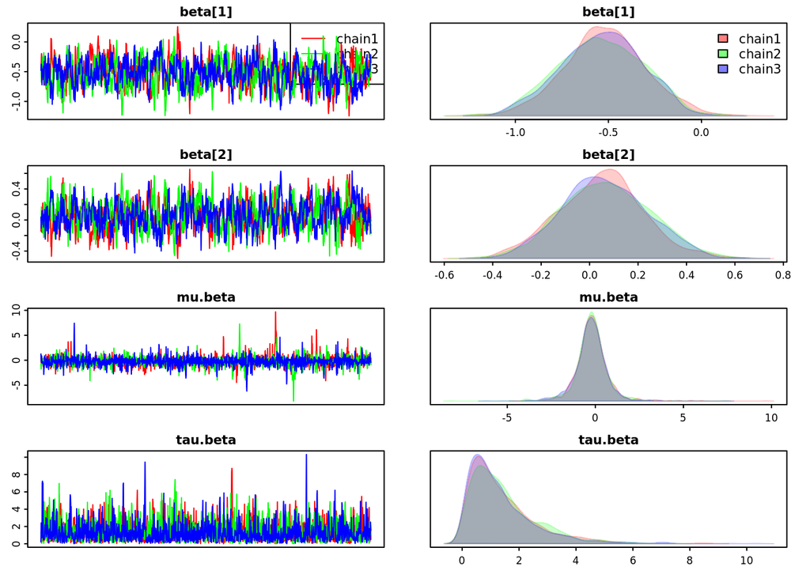

```r
betaChain <- prepParamForChainCheck(samplesList = model1$samples,
                                    param = "beta",
                                    unwantted = "sd")
# dev.off()
basicMCMCplots::chainsPlot(samplesList = betaChain)
```

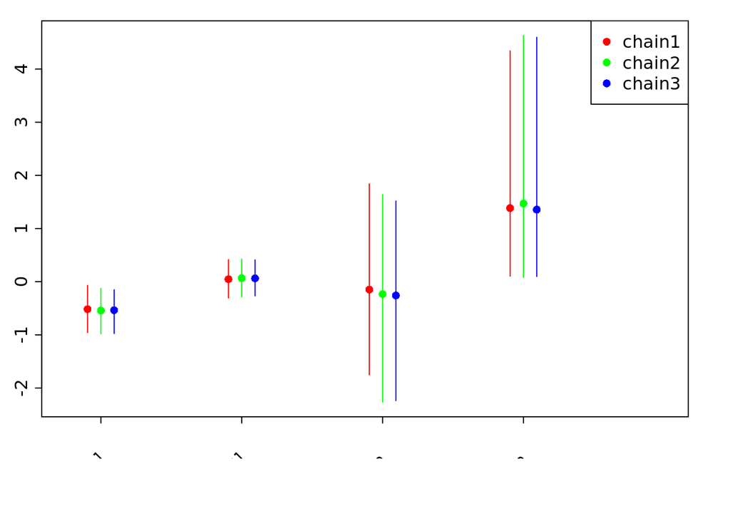

```r
# dev.off()
basicMCMCplots::chainsSummary(samplesList = betaChain)
```

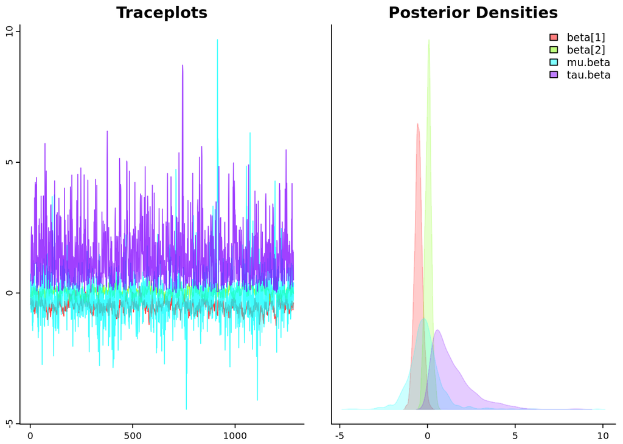

```r
# dev.off()
basicMCMCplots::samplesPlot(samples = betaChain)
```

After looking into chain mixing, we check lambda. Note that this is the summary average, not original posterior.

```r
# Original densities
originalDensities <- prepInputs(url = "https://drive.google.com/open?id=1KOmGJxRivRNgc8AAoCrinl7-ZHQOPUGm",
                     destinationPath = file.path(getwd(), "outputs/posthocAnalysis/bayesian/"),
                     fun = "readRDS")
```

```
## Running preProcess
```

[output not shown]

```
##   File on Google Drive is 8.3 Kb
```

```
## targetFile was not supplied; guessed and will try originalDensities.rds. If this is incorrect, please supply targetFile
```

```
## Preparing: originalDensities.rds
```

```
## Checking local files...
```

```
## Finished checking local files.
```

```
##   Skipping download: originalDensities.rds already present
```

```
## Loading object into R
```

```r
modelDT <- data.table(model1$summary$all.chains, keep.rownames = TRUE)
lambda <- modelDT[rn %in% grepMulti(modelDT$rn, patterns = "lambda"),]
hist(originalDensities, main = "Average density: Original", xlim = c(0, 3), breaks = 15) # Average density
```

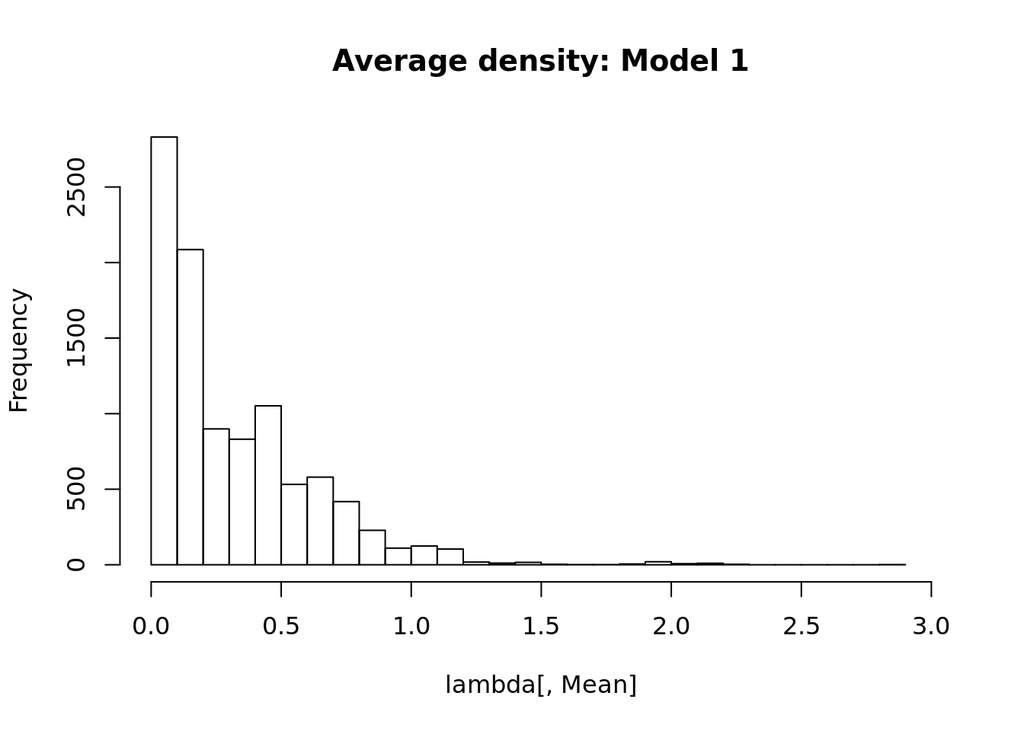

```r
hist(lambda[, Mean], main = "Average density: Model 1", xlim = c(0, 3), breaks = 30) # Average density
```

Now the coefficient for disturbance, beta. Beta[1] is the neighborhood disturbance coefficient, and beta[2] is the local disturbance coefficient.

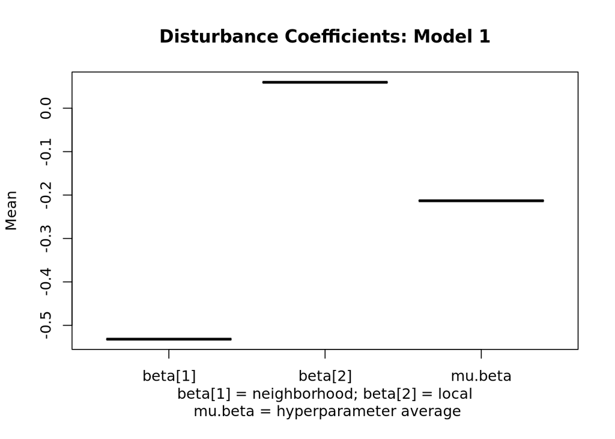

```r
beta <- c(grepMulti(modelDT$rn, patterns = c("beta", "1")),
                   grepMulti(modelDT$rn, patterns = c("beta", "2")),
                   grepMulti(modelDT$rn, patterns = c("beta", "mu")))
dt <- data.frame(modelDT[rn %in% beta,c("rn", "Mean")])
boxplot(Mean ~ rn, data = dt, main = paste0("Disturbance Coefficients: ", whichModel),
        xlab = "beta[1] = neighborhood; beta[2] = local\n mu.beta = hyperparameter average")
```

Now we look at the random effects for parameters: Year and Cluster

```r
RE <- c(grepMulti(modelDT$rn, patterns = c("YearRanEff")),
          grepMulti(modelDT$rn, patterns = c("clusterRanEff")),
        grepMulti(modelDT$rn, patterns = c("phi")))
modelDT[rn %in% RE,]
```

```
##                      rn         Mean       Median    St.Dev.  95%CI_low
##   1:      YearRanEff[1] -0.015035866 -0.002782033 1.43232239 -2.7500736
##   2:      YearRanEff[2]  0.044722520  0.006729343 1.49146598 -2.9074816
##   3:      YearRanEff[3]  0.007378272  0.028230499 1.45147655 -2.8819849
##   4:      YearRanEff[4]  0.006079351  0.019781967 1.45328944 -3.0129511
##   5:      YearRanEff[5]  0.025765484  0.020517442 1.45503884 -2.7288044
##  ---
## 201: clusterRanEff[190]  0.015639628 -0.008072409 1.38040456 -2.7279118
## 202: clusterRanEff[191]  0.026757800  0.038210601 1.34826103 -2.6652151
## 203: clusterRanEff[192]  0.014161197  0.015384610 1.36147728 -2.7382575
## 204: clusterRanEff[193]  0.016414000  0.015507867 1.34333778 -2.7967802
## 205:                phi  0.406650041  0.404709651 0.02195851  0.3682934
##      95%CI_upp
##   1: 2.8631158
##   2: 3.1908744
##   3: 3.0227997
##   4: 2.8941921
##   5: 3.0001469
##  ---
## 201: 2.7265686
## 202: 2.8569172
## 203: 2.7723027
## 204: 2.6716724
## 205: 0.4544208
```

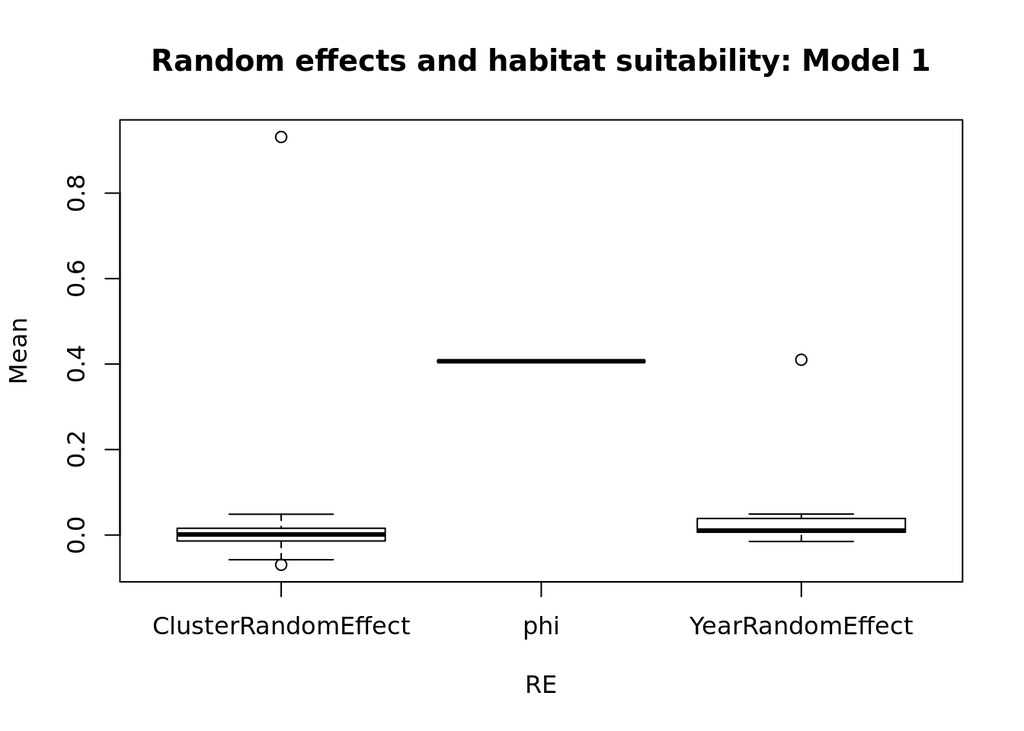

```r
dtRE <- data.frame(modelDT[rn %in% RE, c("rn", "Mean")])
# count how many
ys <- length(grepMulti(dtRE$rn, "Year"))
cls <- length(grepMulti(dtRE$rn, "cluster"))
ph <- length(grepMulti(dtRE$rn, "phi"))
dtRE$RE <- c(rep("YearRandomEffect", times = ys), rep("ClusterRandomEffect", times = cls), rep("phi", times = ph))
boxplot(Mean ~ RE, data = dtRE, main = paste0("Random effects and habitat suitability: ", whichModel))
```

At last, we check habitat suitability: omega

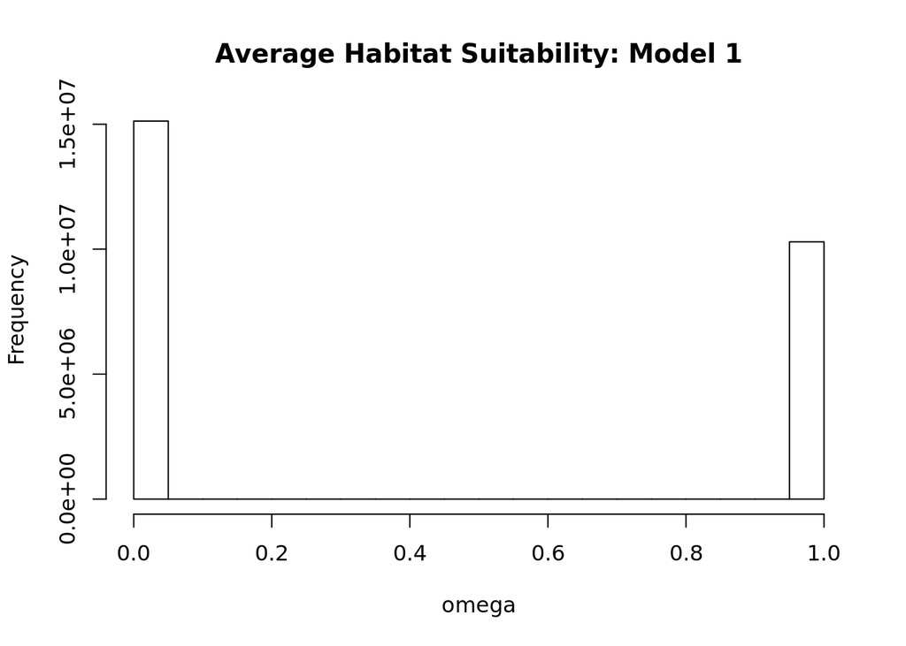

```r
chain2 <- data.table(model1$samples$chain2, keep.rownames = TRUE, check.names = TRUE)
omegaNames <- grepMulti(names(chain2), patterns = "omega")
omega <- chain2[, grepMulti(names(chain2), patterns = "omega")]
chain2Omega <- as.numeric(unlist(x = chain2[, ..omega], recursive = TRUE))

chain2 <- data.table(model1$samples$chain2, keep.rownames = TRUE, check.names = TRUE)
omegaNames <- grepMulti(names(chain2), patterns = "omega")
omega <- chain2[, grepMulti(names(chain2), patterns = "omega")]
allOmega <- c(chain2Omega, as.numeric(unlist(x = chain2[, ..omega], recursive = TRUE)))
hist(allOmega, main = paste0("Average Habitat Suitability: ", whichModel), xlab = "omega")
```

### Model 2:

```r
          ################################### MODEL 2: 2 equations + ZI
    iSMCode <- nimbleCode({

      ######## PRIORS ########
      #Zero inflation - habitat suitability
      phi ~ dunif(0, 1) # proportion of suitable sites (we need to keep phi between 0 and 1)

      # Coefficient for disturbance
      mu.beta ~ dunif(-40, 40)
      tau.beta ~ T(dgamma(1, 1), 0.01, 100)
      sd.beta <- 1/pow(tau.beta, 2) # cluster heterogeneity in lambda
      for (b in 1:Nbeta) {
        beta[b] ~ dnorm(mu.beta, tau.beta) # Hyperparameter for beta coefficients # No idea what to put here!
      }
      tau.NN ~ T(dgamma(1, 1), 0.01, 100)
      sd.NN <- 1/pow(tau.NN, 2) # cluster heterogeneity in NN

      # Random effect
      tau.clusters ~ T(dgamma(1, 1), 0.01, 100)
      sd.cluster <- 1/pow(tau.clusters, 2) # year heterogeneity in lambda
      tau.year ~ T(dgamma(1, 1), 0.01, 100)
      sd.year <- 1/pow(tau.year, 2) # cluster heterogeneity in lambda
      for (j in 1:NClusters) {
        clusterRanEff[j] ~ dnorm(0, tau.clusters) # Note plural on tau.clusters, different than tau.clusters
        # random cluster effects in log(density)
      }
      for (y in 1:NYears) {
        YearRanEff[y] ~ dnorm(0, tau.year)
        # random year effects in log(density)
      }

      ##### END OF PRIORS ####

      for (i in 1:nvisits){ # each sample point / each row of the data table
        omega[i] ~ dbern(phi) # Habitat suitability --> zero inflation (if phi = 0, unsuitable)
        # Neighborhood scale
        yearInd <- YearIndex[i]
        clusterInd <- ClusterIndex[i]

        logNN[i] ~ dnorm(loglambdaN[i], tau.NN)
        loglambdaN[i] <- logDensity[i] +
          beta[1] * State_P_500[i] +
          offset[i] +
          clusterRanEff[clusterInd] * switchCluster +
          YearRanEff[yearInd] * switchYear # Random Effects

        # Local scale
        counts[i]  ~ dpois(lambdaLOmega[i])
        lambdaLOmega[i] <- omega[i] * lambdaL[i]
        lambdaL[i] <- exp(loglambdaL[i])
        loglambdaL[i] <- logNN[i] + beta[2] * State_P_100[i] # We can add an interceptL to NN?
      } # end i
    })

    ################################### MODEL

    # Data (doesn't need init)
    iSMdata <- list(counts = currentYearBirdData$counts,
                    logDensity = currentYearBirdData$density, # Its says density, but it really is logDensity
                    State_P_100 = currentYearBirdData$State_P_100,
                    State_P_500 = currentYearBirdData$State_P_500,
                    offset = currentYearBirdData$offset,
                    ClusterIndex = currentYearBirdData$ClusterSP,
                    YearIndex = currentYearBirdData$YYYY)
    # Constants
    nvisits <- NROW(currentYearBirdData)
    NClusters <- length(unique(currentYearBirdData$ClusterSP))
    NYears <- length(unique(currentYearBirdData$YYYY))
    Nbeta <- 2 # Number of different beta coefficients (coming from the same hyperparameter)
    iSMconstants <- list(nvisits = nvisits,
                         NClusters = NClusters,
                         NYears = NYears,
                         Nbeta = Nbeta, # number of coefficients, currently: beta[1] and beta[2]
                         # Switches
                         switchYear = 1, # or 0 to turn off random effects of Year
                         switchCluster = 1 # or 0 to turn off random effects of Cluster
    )

    lambdaL <- runif(1, 0, 5)# Abundance. Needs reasonable values between 0 and 5?
    iSMinits <- list(
      # Coefficients
      phi = runif(1, 0, 1), # ZI part (‘suitability’ of the sample site).
      beta = rep(0, times = Nbeta), # Coefficient for disturbance ~ Has distribution, not sure need to provide
      omega = rep(1, times = nvisits), # Bernoulli of phi, sample site ‘suitability’ ~ Has distribution, not sure need to provide
      logNN = rep(1, times = nvisits), # Distribution of lambda1 ~ Has distribution, not sure need to provide
      lambdaLOmega = currentYearBirdData$counts, # Distribution of counts <- Is assigned, not sure need to provide # REMOVED FOR NOW --> Simplified
      lambdaL = lambdaL, # Local model, poisson of counts <- Is assigned
      loglambdaL = log(lambdaL), # log of lambda2
      tau.year = runif(1, 0.01, 10), # Deviation of year RE ~ Has distribution
      tau.clusters = runif(1, 0.01, 10), # Deviation of cluester RE ~ Has distribution
      tau.beta = runif(1, 0.01, 10), # Deviation of beta hyperparameter ~ Has distribution
      mu.beta = 0,
      tau.NN = runif(1, 0.01, 10), # Deviation of logNN
      YearRanEff = rep(0, times = NYears),
      clusterRanEff = rep(0, times = NClusters)
    )
    params <- c("beta", "mu.beta", "tau.beta", "sd.beta",
                "loglambdaN", "sd.year", "sd.cluster",
                "sd.NN", "logNN", "lambdaL",
                "omega", "lambdaLOmega",
                "phi", "clusterRanEff", "YearRanEff")
  }
```

#### Loading

```r
whichModel <- "Model 2"
model2 <- prepInputs(url = "https://drive.google.com/open?id=1eTWpb-1mxYXX1KYZ66RvrXMB0_zyV1AB",
                       # TRIAL 4: "https://drive.google.com/open?id=1R6EReTfdLHtv8O3EeK1bwayfZgs-n4eh",
                       # TRIAL 3: "https://drive.google.com/open?id=15d7j6wBj09a6XK1mF0C3cFLggrrqCao4",
                       # TRIAL 2: "https://drive.google.com/open?id=17QiG44vd-Tsf-7QZreUz8Vq67UmpDLZH",
                       # TRIAL 1: https://drive.google.com/open?id=1774Hwx9yFVkOn58eI5rEdGTerve6aqOA",
                     destinationPath = destPath,
                     fun = "readRDS", targetFile = "model2.rds")
```

```
## Running preProcess
```

```
## Preparing: model2.rds
```

```
## Checking local files...
```

```
## Finished checking local files.
```

```
##   File on Google Drive is 1011.4 Mb
##   File on Google Drive is 1011.4 Mb
```

```
##   File on Google Drive is 1011.4 Mb
```

```
## File downloaded:
##   * model2.rds
## Saved locally as:
##   * /tmp/RtmpnKOIs1/reproducible/ADt4Yh/model2.rds
```

```
## Checking local files...
```

```
## Finished checking local files.
```

```
## Appending checksums to CHECKSUMS.txt. If you see this message repeatedly,
##   you can specify targetFile (and optionally alsoExtract) so it knows
##   what to look for.
```

```
## Checking local files...
```

```
## Finished checking local files.
```

```
## Loading object into R
```

```
## Saving large object (cacheId: 6ad7e564d3f526ac) to Cache: 1.5 Gb
```

#### Plots

First of all, we should check chain mixing. We use the function `chainsPlot` from the package `basicMCMCplots`. OBS.: These will likely not work in RStudio server.

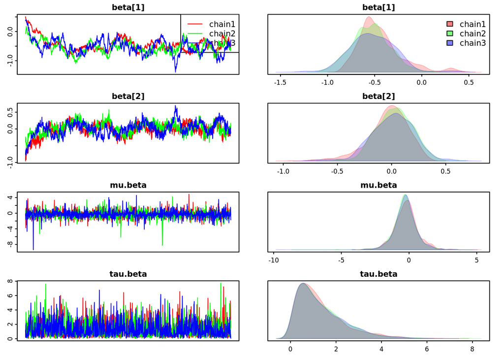

```r
betaChain <- prepParamForChainCheck(samplesList = model2$samples,
                                    param = "beta",
                                    unwantted = "sd")
# dev.off()
basicMCMCplots::chainsPlot(samplesList = betaChain)
```

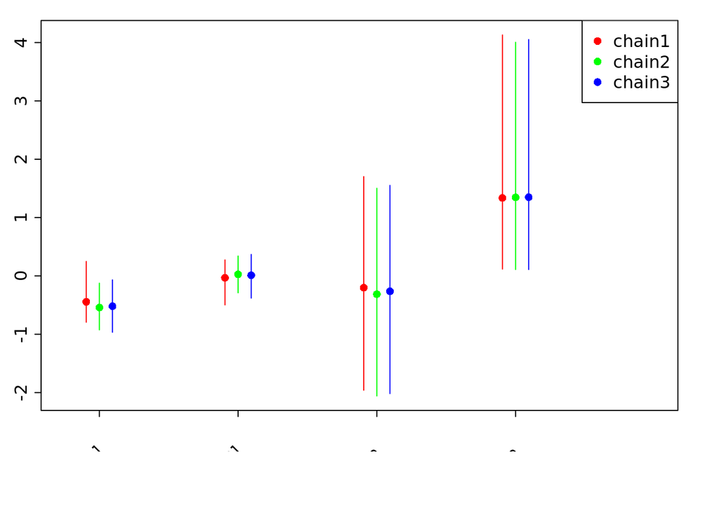

```r
# dev.off()
basicMCMCplots::chainsSummary(samplesList = betaChain)
```

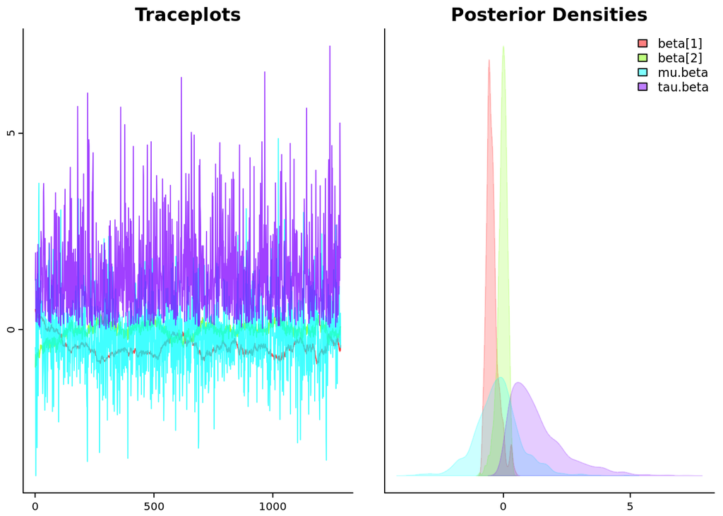

```r
# dev.off()
basicMCMCplots::samplesPlot(samples = betaChain)
```

After looking into chain mixing, we check lambda. Note that this is the summary average, not original posterior.

```r
# Estimated densities
modelDT <- data.table(model2$summary$all.chains, keep.rownames = TRUE)
lambdaL <- modelDT[rn %in% grepMulti(modelDT$rn, patterns = "lambdaL"),]
lambdaN <- modelDT[rn %in% grepMulti(modelDT$rn, patterns = "lambdaN"),]
hist(originalDensities, main = "Average density: Original", xlim = c(0, 3), breaks = 15) # Average density
```

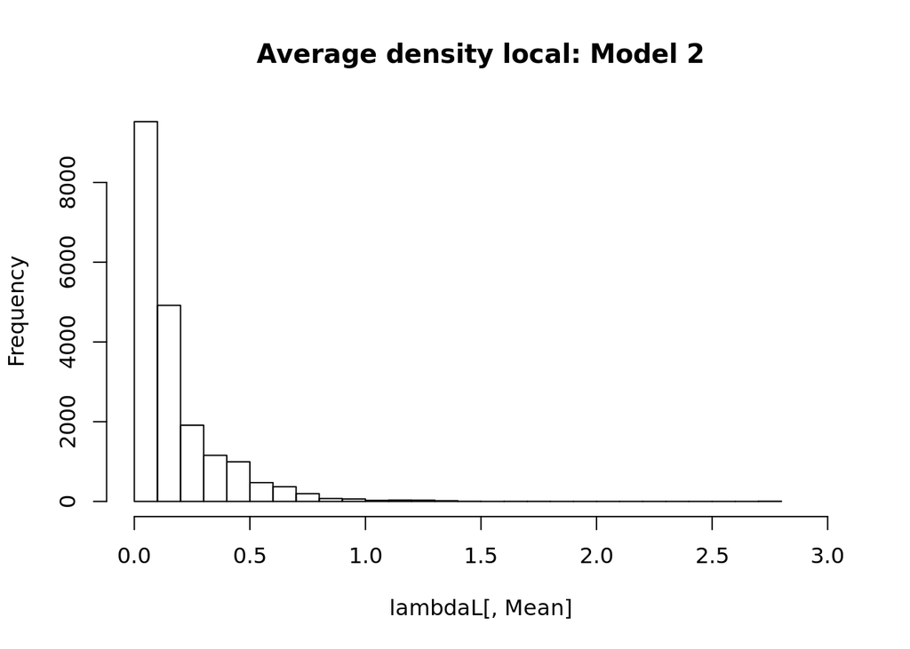

```r
hist(lambdaL[,Mean], main = paste0("Average density local: ", whichModel), xlim = c(0, 3), breaks = 30) # Average density
```

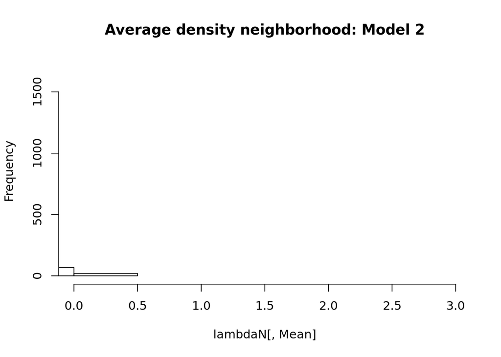

```r
hist(lambdaN[,Mean], main = paste0("Average density neighborhood: ", whichModel), xlim = c(0, 3), breaks = 30) # Average density
```

Now the coefficient for disturbance, beta. Beta[1] is the neighborhood disturbance coefficient, and beta[2] is the local disturbance coefficient.

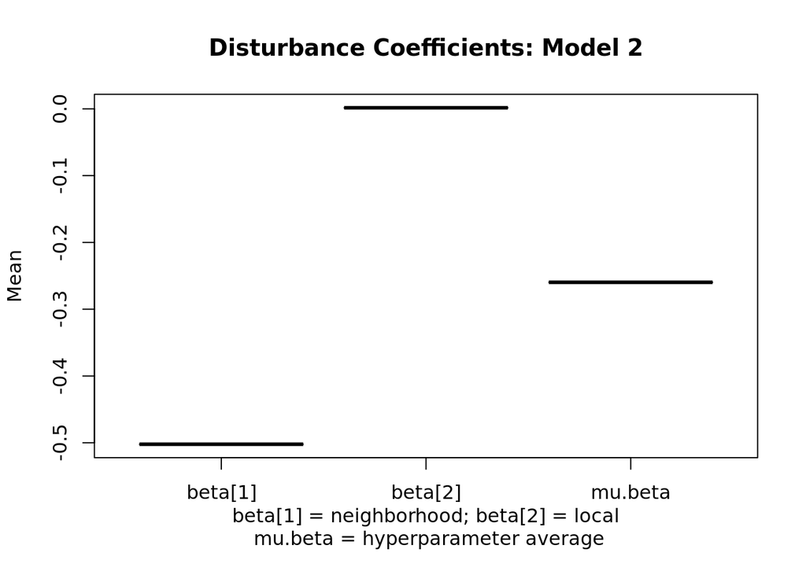

```r
beta <- c(grepMulti(modelDT$rn, patterns = c("beta", "1")),
                   grepMulti(modelDT$rn, patterns = c("beta", "2")),
                   grepMulti(modelDT$rn, patterns = c("beta", "mu")))
dt <- data.frame(modelDT[rn %in% beta,c("rn", "Mean")])
boxplot(Mean ~ rn, data = dt, main = paste0("Disturbance Coefficients: ", whichModel),
        xlab = "beta[1] = neighborhood; beta[2] = local\n mu.beta = hyperparameter average")
```

Now we look at the random effects for parameters: Year and Cluster

```r
RE <- c(grepMulti(modelDT$rn, patterns = c("YearRanEff")),
          grepMulti(modelDT$rn, patterns = c("clusterRanEff")),
        grepMulti(modelDT$rn, patterns = c("phi")))
modelDT[rn %in% RE,]
```

```
##                      rn         Mean       Median   St.Dev.  95%CI_low
##   1:      YearRanEff[1] -0.018901412 -0.013527192 1.4213237 -2.6509152
##   2:      YearRanEff[2] -0.018944842 -0.022602157 1.4035417 -2.7533072
##   3:      YearRanEff[3] -0.015267520 -0.025246178 1.4535951 -2.8325384
##   4:      YearRanEff[4] -0.002245697  0.018751115 1.4056444 -2.8777943
##   5:      YearRanEff[5]  0.011598960 -0.019802876 1.3940598 -2.6337054
##  ---
## 201: clusterRanEff[190]  0.025664080  0.019919014 1.3370727 -2.7036982
## 202: clusterRanEff[191]  0.047735124  0.009927774 1.3613029 -2.4541792
## 203: clusterRanEff[192]  0.016726985  0.018892848 1.2714559 -2.6453733
## 204: clusterRanEff[193]  0.030367254  0.013451093 1.3092495 -2.5483244
## 205:                phi  0.601906996  0.593458793 0.1067273  0.4213053
##      95%CI_upp
##   1: 3.0218814
##   2: 2.7874442
##   3: 2.8674235
##   4: 2.6758088
##   5: 2.8978450
##  ---
## 201: 2.7671086
## 202: 2.6485469
## 203: 2.4992623
## 204: 2.6925720
## 205: 0.8017734
```

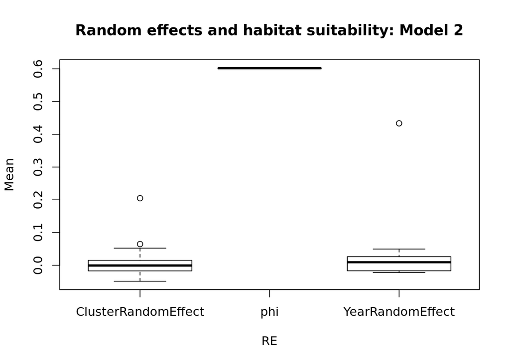

```r
dtRE <- data.frame(modelDT[rn %in% RE, c("rn", "Mean")])
# count how many
ys <- length(grepMulti(dtRE$rn, "Year"))
cls <- length(grepMulti(dtRE$rn, "cluster"))
ph <- length(grepMulti(dtRE$rn, "phi"))
dtRE$RE <- c(rep("YearRandomEffect", times = ys), rep("ClusterRandomEffect", times = cls), rep("phi", times = ph))
boxplot(Mean ~ RE, data = dtRE, main = paste0("Random effects and habitat suitability: ", whichModel))
```

At last, we check habitat suitability: omega

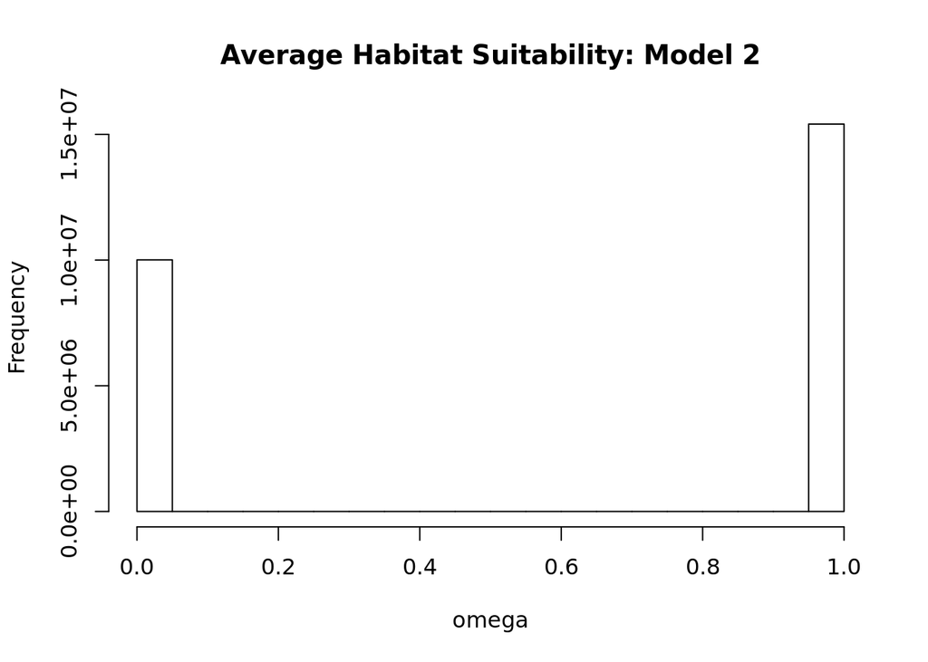

```r
chain2 <- data.table(model2$samples$chain2, keep.rownames = TRUE, check.names = TRUE)
omegaNames <- grepMulti(names(chain2), patterns = "omega")
omega <- chain2[, grepMulti(names(chain2), patterns = "omega")]
chain2Omega <- as.numeric(unlist(x = chain2[, ..omega], recursive = TRUE))

chain2 <- data.table(model2$samples$chain2, keep.rownames = TRUE, check.names = TRUE)
omegaNames <- grepMulti(names(chain2), patterns = "omega")
omega <- chain2[, grepMulti(names(chain2), patterns = "omega")]
allOmega <- c(chain2Omega, as.numeric(unlist(x = chain2[, ..omega], recursive = TRUE)))
hist(allOmega, main = paste0("Average Habitat Suitability: ", whichModel), xlab = "omega")
```

### Model 3:

Model 3 is composed of one equation, where the coefficients for disturbance come from the same hyperprior, but has no Zero Inflation.

```r
         ################################### MODEL 3: 1 equation no ZI
    iSMCode <- nimbleCode({

      ######## PRIORS ########
      #Zero inflation - habitat suitability

      # Coefficient for disturbance
      mu.beta ~ dunif(-40, 40)
      tau.beta ~ T(dgamma(1, 1), 0.01, 100)
      sd.beta <- 1/pow(tau.beta, 2) # cluster heterogeneity in lambda
      for (b in 1:Nbeta) {
        beta[b] ~ dnorm(mu.beta, tau.beta) # Hyperparameter for beta coefficients # No idea what to put here!
      }

      # Random effect
      tau.clusters ~ T(dgamma(1, 1), 0.01, 100)
      sd.cluster <- 1/pow(tau.clusters, 2) # year heterogeneity in lambda
      tau.year ~ T(dgamma(1, 1), 0.01, 100)
      sd.year <- 1/pow(tau.year, 2) # cluster heterogeneity in lambda
      for (j in 1:NClusters) {
        clusterRanEff[j] ~ dnorm(0, tau.clusters) # Note plural on tau.clusters, different than tau.clusters
        # random cluster effects in log(density)
      }
      for (y in 1:NYears) {
        YearRanEff[y] ~ dnorm(0, tau.year)
        # random year effects in log(density)
      }

      ##### END OF PRIORS ####

      for (i in 1:nvisits){ # each sample point / each row of the data table
        # Local scale
        yearInd <- YearIndex[i]
        clusterInd <- ClusterIndex[i]
        counts[i]  ~ dpois(lambda[i])
        lambda[i] <- exp(loglambda[i])
        loglambda[i] <- logDensity[i] + beta[1] * State_P_500[i] + beta[2] * State_P_100[i] + offset[i] +
          clusterRanEff[clusterInd] * switchCluster +
          YearRanEff[yearInd] * switchYear # Random Effects
      } # end i
    })

    ################################### MODEL

    # Data (doesn't need init)
    iSMdata <- list(counts = currentYearBirdData$counts,
                    logDensity = currentYearBirdData$density,
                    State_P_100 = currentYearBirdData$State_P_100,
                    State_P_500 = currentYearBirdData$State_P_500,
                    offset = currentYearBirdData$offset,
                    ClusterIndex = currentYearBirdData$ClusterSP,
                    YearIndex = currentYearBirdData$YYYY)
    # Constants
    nvisits <- NROW(currentYearBirdData)
    NClusters <- length(unique(currentYearBirdData$ClusterSP))
    NYears <- length(unique(currentYearBirdData$YYYY))
    Nbeta <- 2 # Number of different beta coefficients (coming from the same hyperparameter)
    iSMconstants <- list(nvisits = nvisits,
                         NClusters = NClusters,
                         NYears = NYears,
                         Nbeta = Nbeta, # number of coefficients, currently: beta[1] and beta[2]
                         # Switches
                         switchYear = 1, # or 0 to turn off random effects of Year
                         switchCluster = 1 # or 0 to turn off random effects of Cluster
    )

    iSMinits <- list(
      # Coefficients
      beta = rep(0, times = Nbeta), # Coefficient for disturbance ~ Has distribution, not sure need to provide
      tau.year = runif(1, 0.01, 10), # Deviation of year RE ~ Has distribution
      tau.clusters = runif(1, 0.01, 10), # Deviation of cluester RE ~ Has distribution
      tau.beta = runif(1, 0.01, 10), # Deviation of beta hyperparameter ~ Has distribution
      mu.beta = 0,
      YearRanEff = rep(0, times = NYears),
      clusterRanEff = rep(0, times = NClusters)
    )

    params <- c("mu.beta", "beta", "tau.beta", "sd.beta",
                "lambda",
                "clusterRanEff", "YearRanEff")
  }
```

#### Loading

```r
whichModel <- "Model 3"
model3 <- prepInputs(url = "https://drive.google.com/open?id=1HyHw09Uh2fQPQ0TUnjcutQ9ox-yTaSDJ",
                       # TRIAL 4: "https://drive.google.com/open?id=1d20NQmaGxD71JnFn5LWf9HW3M6esi__b",
                       # TRIAL 3: "https://drive.google.com/open?id=1MLKMU-oz7MgnIhJ8XoqLZ_f5ki57SWm2",
                       # TRIAL 2: "https://drive.google.com/open?id=1oVzMYvI7YXvL6TsgSh8BnYCda7GOAU2E",
                       # TRIAL 1: "https://drive.google.com/open?id=1UWoaLN1lNOjVQBSzSD2WpA1185i1x9ne",
                     destinationPath = destPath,
                     fun = "readRDS", targetFile = "model3.rds")
```

```
## Running preProcess
```

```
## Preparing: model3.rds
```

```
## Checking local files...
```

```
## Finished checking local files.
```

```
##   File on Google Drive is 271.5 Mb
##   File on Google Drive is 271.5 Mb
```

```
##   File on Google Drive is 271.5 Mb
```

```
## File downloaded:
##   * model3.rds
## Saved locally as:
##   * /tmp/RtmpnKOIs1/reproducible/3MLtrT/model3.rds
```

```
## Checking local files...
```

```
## Finished checking local files.
```

```
## Appending checksums to CHECKSUMS.txt. If you see this message repeatedly,
##   you can specify targetFile (and optionally alsoExtract) so it knows
##   what to look for.
```

```
## Checking local files...
```

```
## Finished checking local files.
```

```
## Loading object into R
```

```
## Saving large object (cacheId: 9fc8d1dac45b7bb4) to Cache: 303.5 Mb
```

#### Plots

First of all, we should check chain mixing. We use the function `chainsPlot` from the package `basicMCMCplots`. OBS.: These will likely not work in RStudio server.

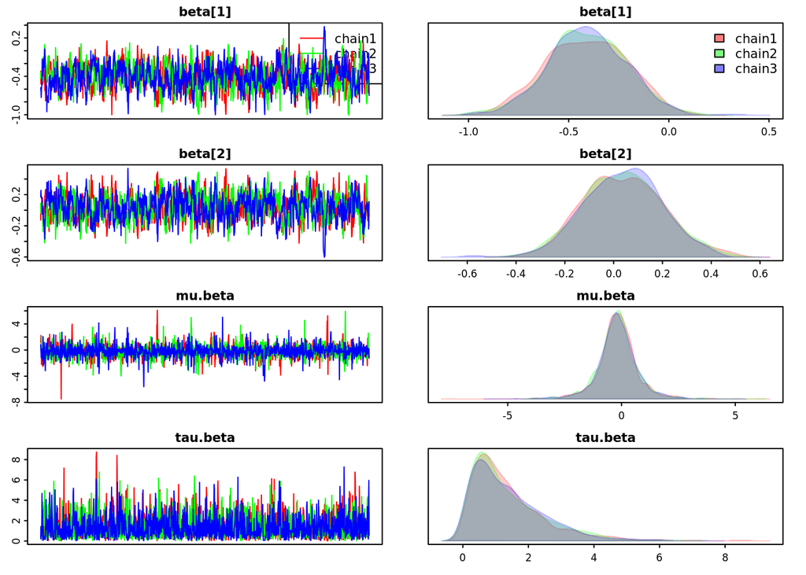

```r
betaChain <- prepParamForChainCheck(samplesList = model3$samples,
                                    param = "beta",
                                    unwantted = "sd")
# dev.off()
basicMCMCplots::chainsPlot(samplesList = betaChain)
```

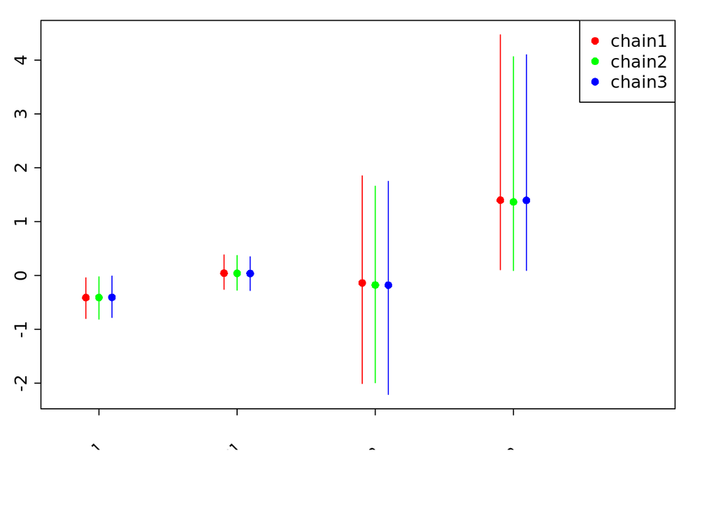

```r
# dev.off()
basicMCMCplots::chainsSummary(samplesList = betaChain)
```

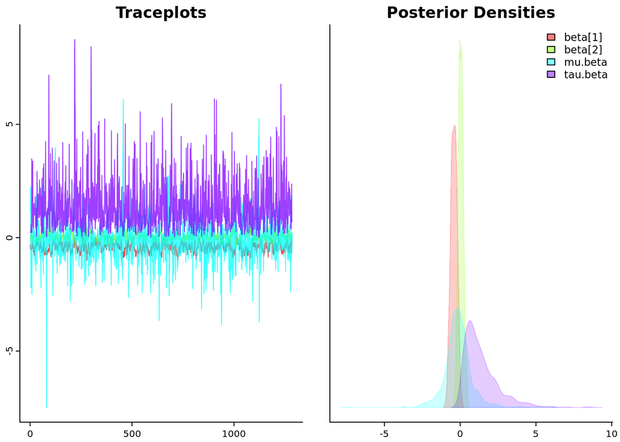

```r
# dev.off()
basicMCMCplots::samplesPlot(samples = betaChain)
```

After looking into chain mixing, we check lambda. Note that this is the summary average, not original posterior.

```r
# Original densities
originalDensities <- prepInputs(url = "https://drive.google.com/open?id=1KOmGJxRivRNgc8AAoCrinl7-ZHQOPUGm",
                     destinationPath = file.path(getwd(), "outputs/posthocAnalysis/bayesian/"),
                     fun = "readRDS")
```

```
## Running preProcess
```

```
##   File on Google Drive is 8.3 Kb
```

```
## targetFile was not supplied; guessed and will try originalDensities.rds. If this is incorrect, please supply targetFile
```

```
## Preparing: originalDensities.rds
```

```
## Checking local files...
```

```
## Finished checking local files.
```

```
##   Skipping download: originalDensities.rds already present
```

```
## Loading object into R
```

```
##   ...(Object to retrieve (ab2db979dcb488d6.rds))
```

```
##      loaded cached result from previous do.call call,
```

```r
modelDT <- data.table(model3$summary$all.chains, keep.rownames = TRUE)
lambda <- modelDT[rn %in% grepMulti(modelDT$rn, patterns = "lambda"),]
hist(originalDensities, main = "Average density: Original", xlim = c(0, 3), breaks = 15) # Average density
```

[output not shown]

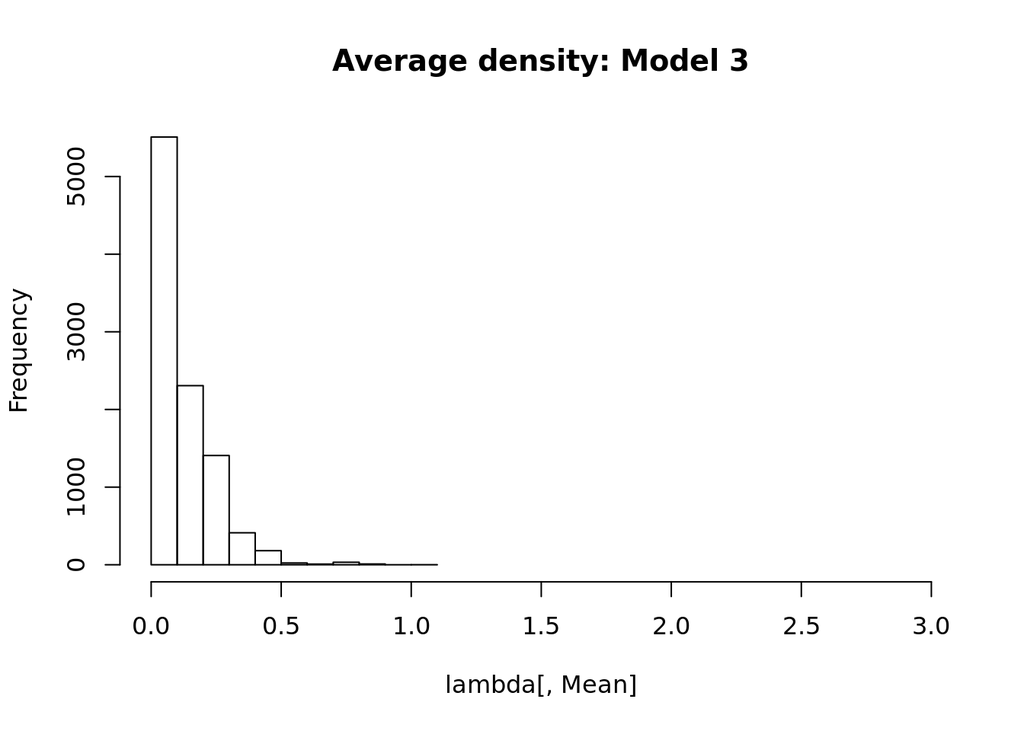

```r
hist(lambda[, Mean], main = paste0("Average density: ", whichModel), xlim = c(0, 3), breaks = 15) # Average density
```

Now the coefficient for disturbance, beta. Beta[1] is the neighborhood disturbance coefficient, and beta[2] is the local disturbance coefficient.

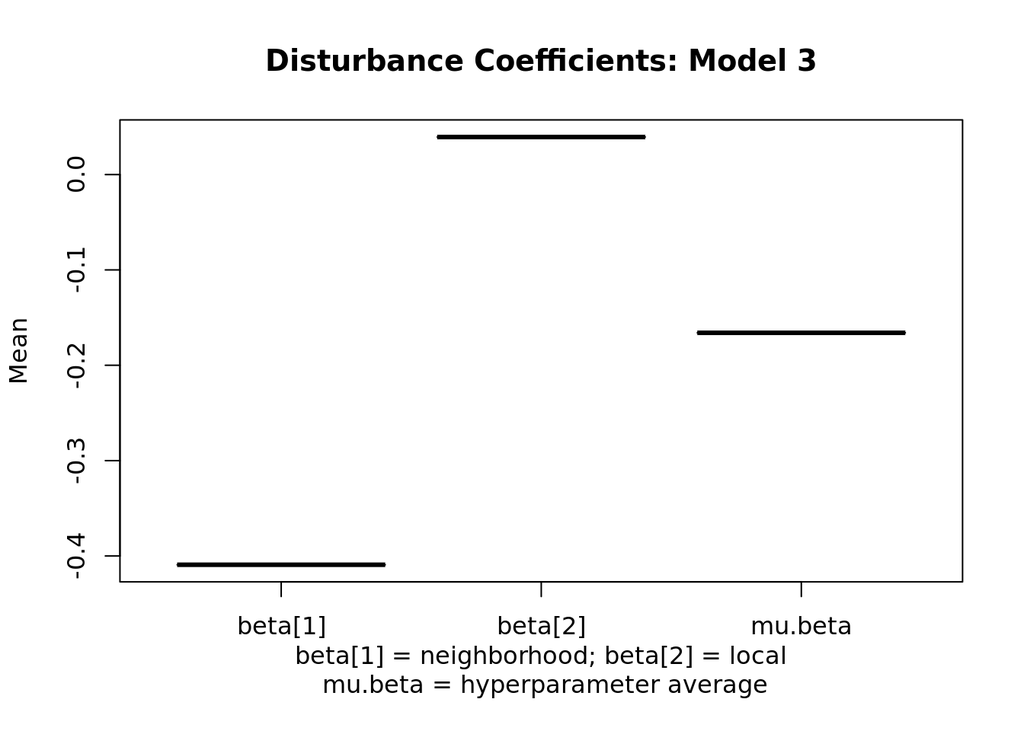

```r
beta <- c(grepMulti(modelDT$rn, patterns = c("beta", "1")),
                   grepMulti(modelDT$rn, patterns = c("beta", "2")),
                   grepMulti(modelDT$rn, patterns = c("beta", "mu")))
dt <- data.frame(modelDT[rn %in% beta,c("rn", "Mean")])
boxplot(Mean ~ rn, data = dt, main = paste0("Disturbance Coefficients: ", whichModel),
        xlab = "beta[1] = neighborhood; beta[2] = local\n mu.beta = hyperparameter average")
```

Now we look at the random effects for parameters: Year and Cluster

```r
RE <- c(grepMulti(modelDT$rn, patterns = c("YearRanEff")),
          grepMulti(modelDT$rn, patterns = c("clusterRanEff")))
modelDT[rn %in% RE,]
```

```
##                      rn         Mean       Median  St.Dev. 95%CI_low 95%CI_upp
##   1:      YearRanEff[1] -0.029028198 -0.005421543 1.443232 -3.125814  2.779680
##   2:      YearRanEff[2]  0.007597616  0.002123985 1.396843 -2.786086  2.903715
##   3:      YearRanEff[3]  0.033686367  0.056419106 1.453027 -2.873415  2.858906
##   4:      YearRanEff[4] -0.035912075 -0.005837014 1.434775 -3.107233  2.782831
##   5:      YearRanEff[5] -0.032022561 -0.011452515 1.446622 -3.132168  2.902232
##  ---
## 200: clusterRanEff[189]  0.014652278  0.028401205 1.181081 -2.334399  2.414059
## 201: clusterRanEff[190] -0.024003584 -0.017483138 1.169306 -2.397429  2.343409
## 202: clusterRanEff[191] -0.005143311  0.011315004 1.180582 -2.428451  2.420330
## 203: clusterRanEff[192] -0.021469644 -0.039106541 1.231035 -2.512576  2.422334
## 204: clusterRanEff[193] -0.002741360 -0.034321771 1.192158 -2.393984  2.514402
```

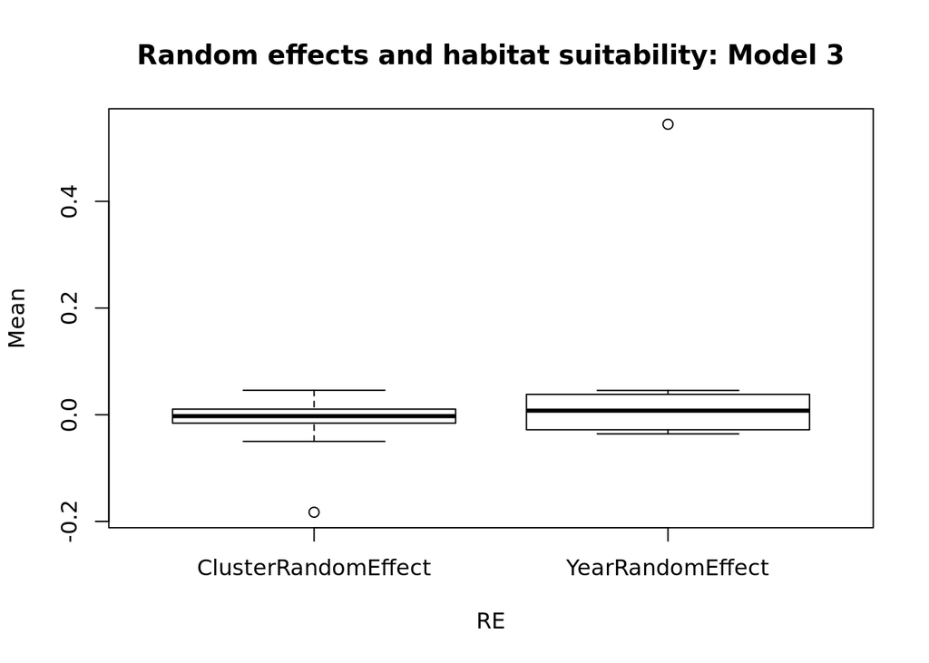

```r
dtRE <- data.frame(modelDT[rn %in% RE, c("rn", "Mean")])
# count how many
ys <- length(grepMulti(dtRE$rn, "Year"))
cls <- length(grepMulti(dtRE$rn, "cluster"))
dtRE$RE <- c(rep("YearRandomEffect", times = ys), rep("ClusterRandomEffect", times = cls))
boxplot(Mean ~ RE, data = dtRE, main = paste0("Random effects and habitat suitability: ", whichModel))
```

### Model 4:

```r
        ################################### MODEL 4: 2 equations no ZI
    iSMCode <- nimbleCode({

      ######## PRIORS ########
      # Coefficient for disturbance
      mu.beta ~ dunif(-40, 40)
      tau.beta ~ T(dgamma(1, 1), 0.01, 100)
      sd.beta <- 1/pow(tau.beta, 2) # cluster heterogeneity in lambda
      for (b in 1:Nbeta) {
        beta[b] ~ dnorm(mu.beta, tau.beta) # Hyperparameter for beta coefficients # No idea what to put here!
      }
      tau.NN ~ T(dgamma(1, 1), 0.01, 100)
      sd.NN <- 1/pow(tau.NN, 2) # cluster heterogeneity in NN

      # Random effect
      tau.clusters ~ T(dgamma(1, 1), 0.01, 100)
      sd.cluster <- 1/pow(tau.clusters, 2) # year heterogeneity in lambda
      tau.year ~ T(dgamma(1, 1), 0.01, 100)
      sd.year <- 1/pow(tau.year, 2) # cluster heterogeneity in lambda
      for (j in 1:NClusters) {
        clusterRanEff[j] ~ dnorm(0, tau.clusters) # Note plural on tau.clusters, different than tau.clusters
        # random cluster effects in log(density)
      }
      for (y in 1:NYears) {
        YearRanEff[y] ~ dnorm(0, tau.year)
        # random year effects in log(density)
      }

      ##### END OF PRIORS ####

      for (i in 1:nvisits){ # each sample point / each row of the data table
        # Neighborhood scale
        yearInd <- YearIndex[i]
        clusterInd <- ClusterIndex[i]

        logNN[i] ~ dnorm(loglambdaN[i], tau.NN)
        loglambdaN[i] <- logDensity[i] +
          beta[1] * State_P_500[i] +
          offset[i] +
          clusterRanEff[clusterInd] * switchCluster +
          YearRanEff[yearInd] * switchYear # Random Effects

        # Local scale
        counts[i]  ~ dpois(lambdaL[i])
        lambdaL[i] <- exp(loglambdaL[i])
        loglambdaL[i] <- logNN[i] + beta[2] * State_P_100[i] # We can add an interceptL to NN?
      } # end i
    })

    ################################### MODEL

    # Data (doesn't need init)
    iSMdata <- list(counts = currentYearBirdData$counts,
                    logDensity = currentYearBirdData$density,
                    State_P_100 = currentYearBirdData$State_P_100,
                    State_P_500 = currentYearBirdData$State_P_500,
                    offset = currentYearBirdData$offset,
                    ClusterIndex = currentYearBirdData$ClusterSP,
                    YearIndex = currentYearBirdData$YYYY)
    # Constants
    nvisits <- NROW(currentYearBirdData)
    NClusters <- length(unique(currentYearBirdData$ClusterSP))
    NYears <- length(unique(currentYearBirdData$YYYY))
    Nbeta <- 2 # Number of different beta coefficients (coming from the same hyperparameter)
    iSMconstants <- list(nvisits = nvisits,
                         NClusters = NClusters,
                         NYears = NYears,
                         Nbeta = Nbeta, # number of coefficients, currently: beta[1] and beta[2]
                         # Switches
                         switchYear = 1, # or 0 to turn off random effects of Year
                         switchCluster = 1 # or 0 to turn off random effects of Cluster
    )

    lambdaL <- runif(1, 0, 5)# Abundance. Needs reasonable values between 0 and 5?
    iSMinits <- list(
      # Coefficients
      beta = rep(0, times = Nbeta), # Coefficient for disturbance ~ Has distribution, not sure need to provide
      logNN = rep(1, times = nvisits), # Distribution of lambda1 ~ Has distribution, not sure need to provide
      lambdaL = lambdaL, # Local model, poisson of counts <- Is assigned
      loglambdaL = log(lambdaL), # log of lambda2
      tau.year = runif(1, 0.01, 10), # Deviation of year RE ~ Has distribution
      tau.clusters = runif(1, 0.01, 10), # Deviation of cluester RE ~ Has distribution
      tau.beta = runif(1, 0.01, 10), # Deviation of beta hyperparameter ~ Has distribution
      mu.beta = 0,
      tau.NN = runif(1, 0.01, 10), # Deviation of NN ~ Has distribution
      YearRanEff = rep(0, times = NYears),
      clusterRanEff = rep(0, times = NClusters)
    )
    params <- c("beta", "mu.beta", "tau.beta", "sd.beta",
                "loglambdaN",
                "logNN", "lambdaL", "sd.year", "sd.cluster",
                "sd.NN",
                "clusterRanEff", "YearRanEff")
  }
```

#### Loading

```r
whichModel <- "Model 4"
model4 <- prepInputs(url = "https://drive.google.com/open?id=1LeHxu3G5dVMWiGEsATbmNaACCdRdk9Ln",
                       # TRIAL 4: "https://drive.google.com/open?id=1WY0R9_Jkf7imMJ5ZqDsH2s9NrwmicPns",
                       # TRIAL 3: "https://drive.google.com/open?id=1HQhyWsSHY8w54yUZPAmnv-Kv-zz-qtj-",
                       # TRIAL 2: "https://drive.google.com/open?id=1yMFNbIF7aPm6nmaqrjnz4518BsO6644L",
                       # TRIAL 1 "https://drive.google.com/open?id=1YvG-FFvimDB_hHtSCsYfeZY9rwKfDjue",
                     destinationPath = destPath,
                     fun = "readRDS", targetFile = "model4.rds")
```

```
## Running preProcess
```

```
## Preparing: model4.rds
```

```
## Checking local files...
```

```
## Finished checking local files.
```

```
##   File on Google Drive is 815.8 Mb
##   File on Google Drive is 815.8 Mb
```

```
##   File on Google Drive is 815.8 Mb
```

```
## File downloaded:
##   * model4.rds
## Saved locally as:
##   * /tmp/RtmpnKOIs1/reproducible/DT9410/model4.rds
```

```
## Checking local files...
```

```
## Finished checking local files.
```

```
## Appending checksums to CHECKSUMS.txt. If you see this message repeatedly,
##   you can specify targetFile (and optionally alsoExtract) so it knows
##   what to look for.
```

```
## Checking local files...
```

```
## Finished checking local files.
```

```
## Loading object into R
```

```
## Saving large object (cacheId: 8acb7accf281286a) to Cache: 898.9 Mb
```

#### Plots

First of all, we should check chain mixing. We use the function `chainsPlot` from the package `basicMCMCplots`. OBS.: These will likely not work in RStudio server.

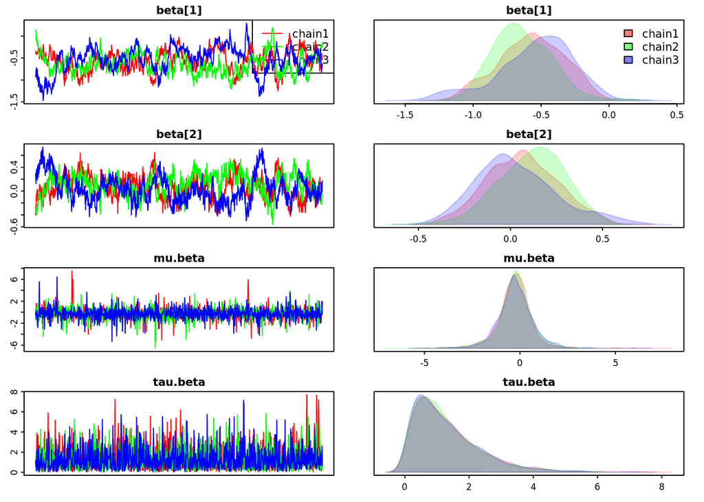

```r
betaChain <- prepParamForChainCheck(samplesList = model4$samples,
                                    param = "beta",
                                    unwantted = "sd")
# dev.off()
basicMCMCplots::chainsPlot(samplesList = betaChain)
```

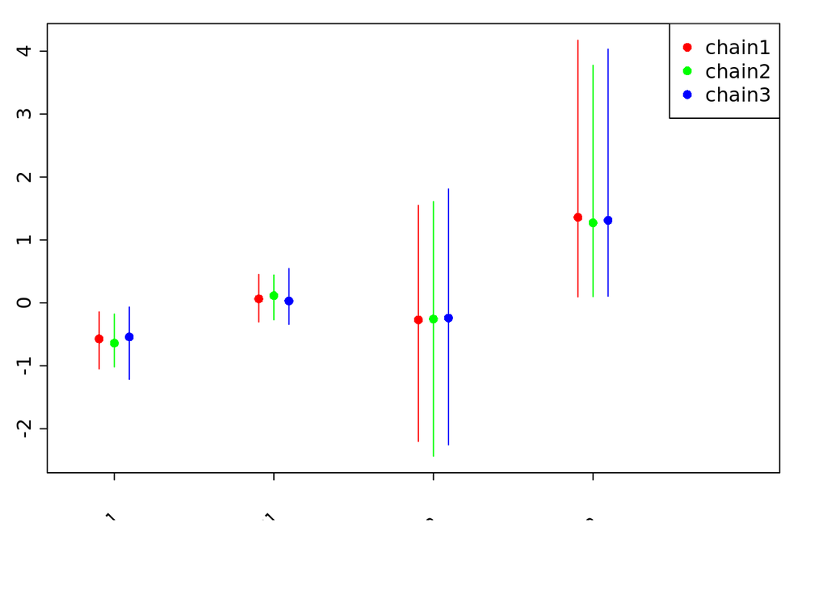

```r
# dev.off()
basicMCMCplots::chainsSummary(samplesList = betaChain)
```

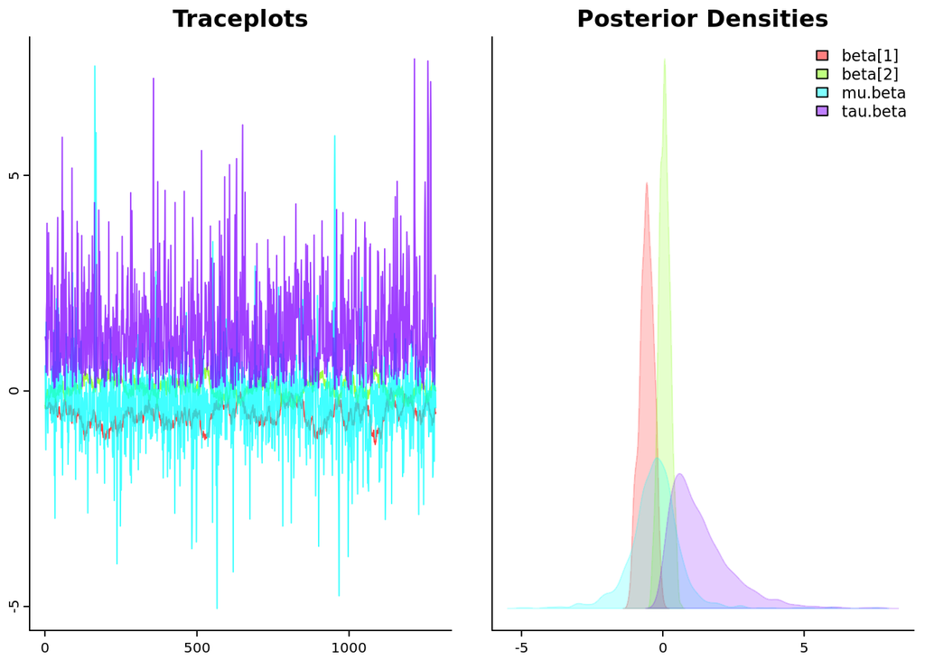

```r
# dev.off()
basicMCMCplots::samplesPlot(samples = betaChain)
```

After looking into chain mixing, we check lambda. Note that this is the summary average, not original posterior.

```r
# Estimated densities
modelDT <- data.table(model4$summary$all.chains, keep.rownames = TRUE)
lambdaL <- modelDT[rn %in% grepMulti(modelDT$rn, patterns = "lambdaL"),]
lambdaN <- modelDT[rn %in% grepMulti(modelDT$rn, patterns = "lambdaN"),]
hist(originalDensities, main = "Average density: Original", xlim = c(0, 3), breaks = 15) # Average density
```

[output not shown]

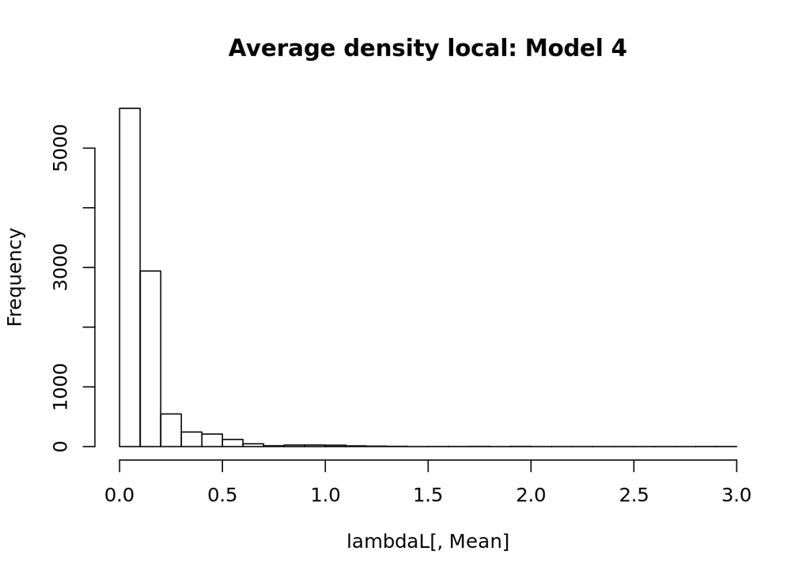

```r
hist(lambdaL[,Mean], main = paste0("Average density local: ", whichModel), xlim = c(0, 3), breaks = 30) # Average density
```

[figure not shown]

```r
hist(lambdaN[,Mean], main = paste0("Average density neighborhood: ", whichModel), xlim = c(0, 3), breaks = 30) # Average density
```

Now the coefficient for disturbance, beta. Beta[1] is the neighborhood disturbance coefficient, and beta[2] is the local disturbance coefficient.

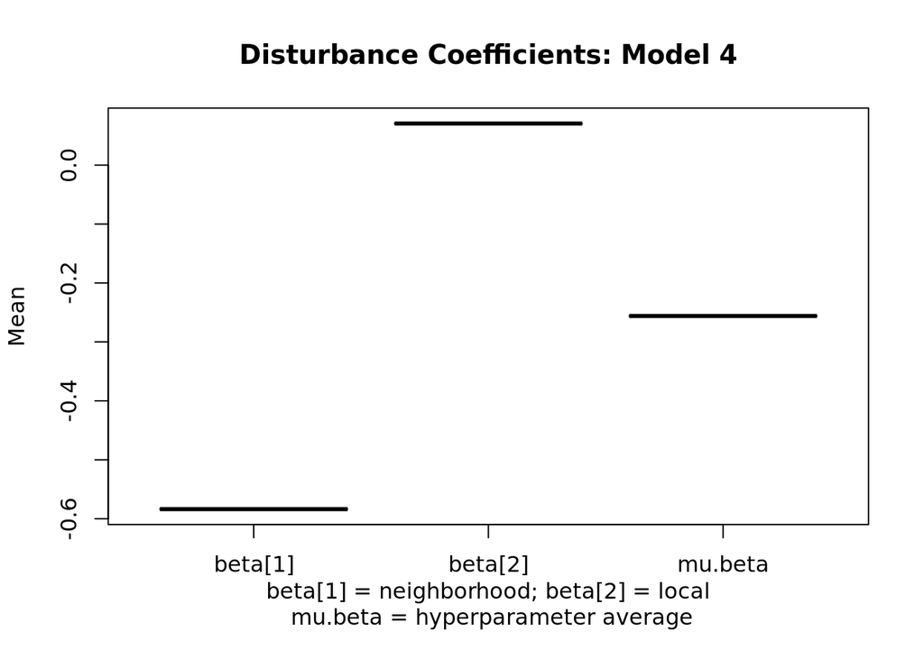

```r
beta <- c(grepMulti(modelDT$rn, patterns = c("beta", "1")),
                   grepMulti(modelDT$rn, patterns = c("beta", "2")),
                   grepMulti(modelDT$rn, patterns = c("beta", "mu")))
dt <- data.frame(modelDT[rn %in% beta,c("rn", "Mean")])
boxplot(Mean ~ rn, data = dt, main = paste0("Disturbance Coefficients: ", whichModel),
        xlab = "beta[1] = neighborhood; beta[2] = local\n mu.beta = hyperparameter average")
```

Now we look at the random effects for parameters: Year and Cluster

```r
RE <- c(grepMulti(modelDT$rn, patterns = c("YearRanEff")),
          grepMulti(modelDT$rn, patterns = c("clusterRanEff")))
modelDT[rn %in% RE,]
```

```
##                      rn         Mean       Median  St.Dev. 95%CI_low 95%CI_upp
##   1:      YearRanEff[1]  0.013419077  0.005254708 1.399901 -2.747124  2.672901
##   2:      YearRanEff[2] -0.011532482 -0.022543758 1.472316 -2.805972  2.813783
##   3:      YearRanEff[3]  0.006522104  0.050885875 1.420772 -2.784716  2.579784
##   4:      YearRanEff[4] -0.022848290 -0.017751765 1.369541 -2.747598  2.625004
##   5:      YearRanEff[5] -0.006744750 -0.032366779 1.452586 -2.795544  2.962284
##  ---
## 200: clusterRanEff[189] -0.020429355 -0.036659331 1.289283 -2.611187  2.728985
## 201: clusterRanEff[190]  0.021797215  0.017692575 1.279078 -2.574065  2.520863
## 202: clusterRanEff[191]  0.012778165  0.031497710 1.235119 -2.541133  2.517956
## 203: clusterRanEff[192] -0.025811222 -0.041337224 1.254106 -2.650489  2.562112
## 204: clusterRanEff[193] -0.007333615 -0.033992174 1.245226 -2.543822  2.571777
```

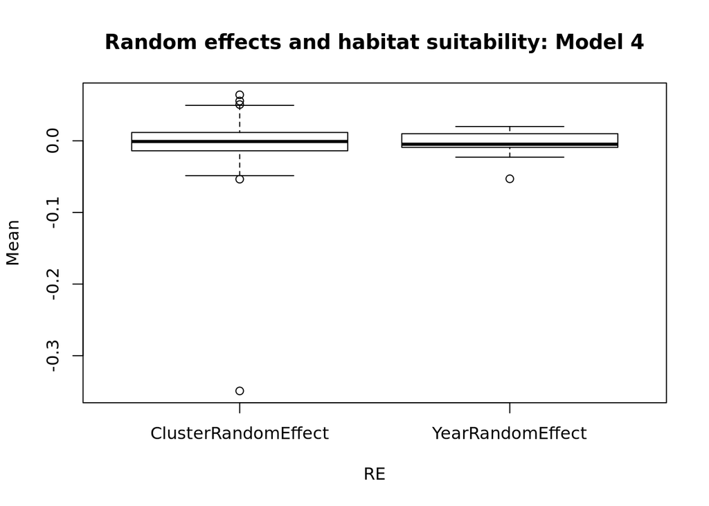

```r
dtRE <- data.frame(modelDT[rn %in% RE, c("rn", "Mean")])
# count how many
ys <- length(grepMulti(dtRE$rn, "Year"))
cls <- length(grepMulti(dtRE$rn, "cluster"))
dtRE$RE <- c(rep("YearRandomEffect", times = ys), rep("ClusterRandomEffect", times = cls))
boxplot(Mean ~ RE, data = dtRE, main = paste0("Random effects and habitat suitability: ", whichModel))
```